# Análisis Inteligente de Datos Trabajo Práctico N° 1 1° C 2023

### 12.

**Elija dos variables cuantitativas, determine la variable explicativa y la variable explicada. Encuentre la ecuación de la recta de regresión lineal que explique la relación entre las variables elegidas. Escriba conclusiones acerca de la significatividad del modelo aplicado. Puede acompañar el modelo de un gráfico adecuado.**

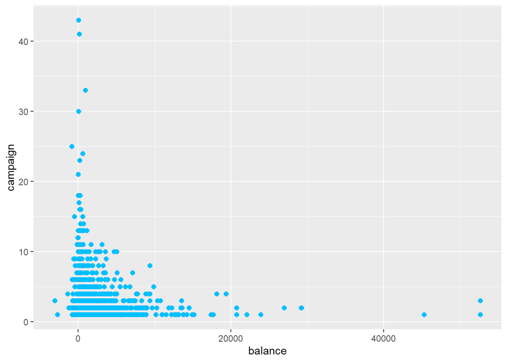

```r
p<-ggplot(muestra,
          aes(x =balance , y = campaign)) +
  geom_point(aes(), colour ="deepskyblue", size=2)
p + xlab("balance") +  ylab("campaign")
```

```r
modelo<-lm(campaign ~ balance,
            data=muestra)

summary(modelo)
```

```
##
## Call:
## lm(formula = campaign ~ balance, data = muestra)
##
## Residuals:
##    Min     1Q Median     3Q    Max
## -1.767 -1.573 -0.615  0.406 40.379
##
## Coefficients:
##               Estimate Std. Error t value Pr(>|t|)
## (Intercept)  2.624e+00  6.986e-02  37.556  < 2e-16 ***
## balance     -5.299e-05  1.904e-05  -2.783  0.00544 **
## ---
## Signif. codes:  0 '***' 0.001 '**' 0.01 '*' 0.05 '.' 0.1 ' ' 1
##
## Residual standard error: 2.813 on 1998 degrees of freedom
## Multiple R-squared:  0.003861,   Adjusted R-squared:  0.003363
## F-statistic: 7.744 on 1 and 1998 DF,  p-value: 0.005439
```

Se calculan los residuos del modelo para chequear los supuestos.

```r
#Calculamos los residuos y los predichos
e<-resid(modelo) # residuos
re<-rstandard(modelo) #residuos estandarizados
pre<-predict(modelo) #predichos
res<-cbind(muestra$balance, muestra$campaign,pre,e,round(re,2))
colnames(res)<-c("balance", "campaign", "Predichos", "Residuos", "residuos std")
head(res)
```

```
##   balance campaign Predichos   Residuos residuos std
## 1     901        3  2.575754  0.4242460         0.15
## 2     -92        4  2.628377  1.3716230         0.49
## 3    4335        1  2.393773 -1.3937730        -0.50
## 4     388        2  2.602940 -0.6029399        -0.21
## 5     127        4  2.616771  1.3832287         0.49
## 6       8       18  2.623078 15.3769224         5.47
```

Evaluamos el supuesto de normalidad de manera gráfica y mediante una prueba de hipótesis.

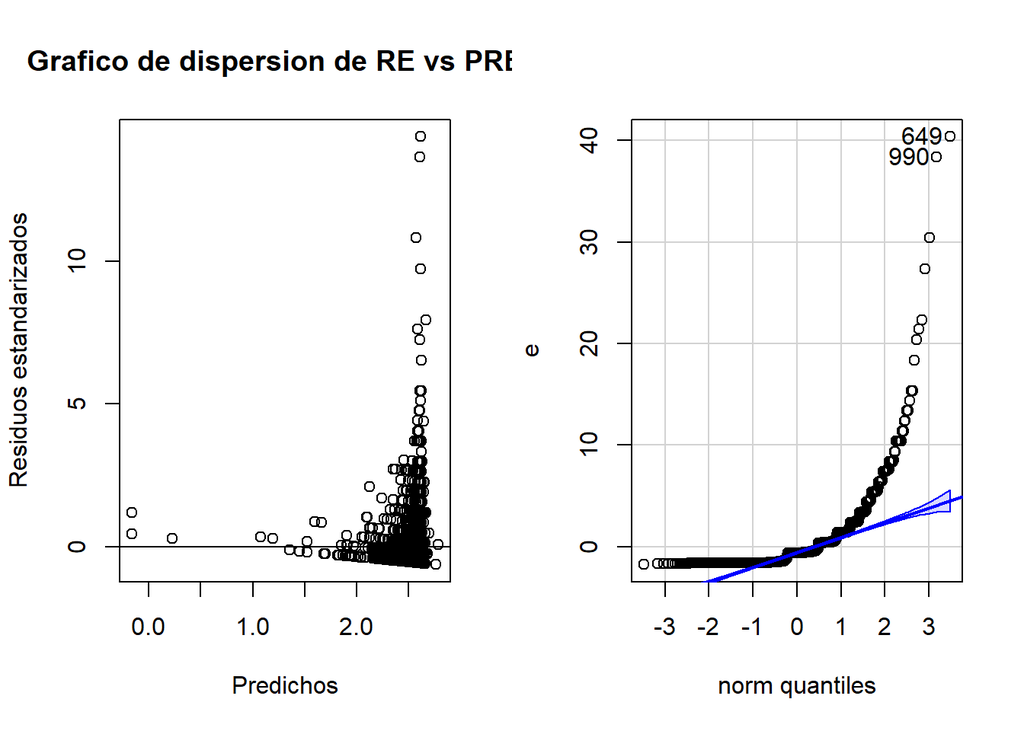

```
## [1] 649 990
```

```r
#Supuestos
par(mfrow = c(1, 2))
plot(pre, re, xlab="Predichos", ylab="Residuos estandarizados",main="Grafico de dispersion de RE vs PRED" )
abline(0,0)
qqPlot(e)
```

Del primer gráfico se desprende que no se cumple el supuesto de que la varianza de los residuos es constante y del segundo que no se cumple que los residuos tengan una distribución normal.

Test de normalidad de Shapiro  
H0: Los residuos siguen una distribución Normal  
H1: Los residuos NO sigue una distribución normal

```r
shapiro.test(e)
```

```
##
##  Shapiro-Wilk normality test
##
## data:  e
## W = 0.53604, p-value < 2.2e-16
```

p-value = 2.2e-16 < 0,05 por ende se rechaza la Hipótesis Nula y se puede afirmar que Los residuos no tienen una distribución Normal con un nivel de significación del 5%.

```r
confint(modelo)#por default es del 95%
```

```
##                     2.5 %        97.5 %
## (Intercept)  2.486503e+00  2.760500e+00
## balance     -9.033995e-05 -1.564784e-05
```

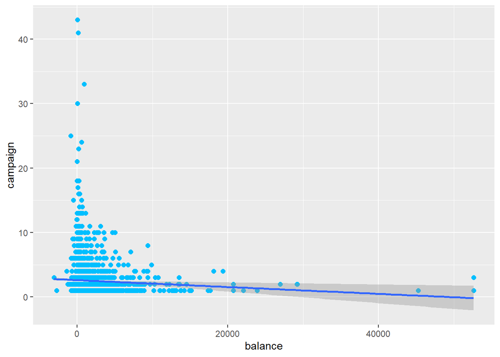

```r
p + geom_smooth(method = "lm",
                se = TRUE)#para mostrar la banda de confianza
```

```r
summary(modelo)
```

```
##
## Call:
## lm(formula = campaign ~ balance, data = muestra)
##
## Residuals:
##    Min     1Q Median     3Q    Max
## -1.767 -1.573 -0.615  0.406 40.379
##
## Coefficients:
##               Estimate Std. Error t value Pr(>|t|)
## (Intercept)  2.624e+00  6.986e-02  37.556  < 2e-16 ***
## balance     -5.299e-05  1.904e-05  -2.783  0.00544 **
## ---
## Signif. codes:  0 '***' 0.001 '**' 0.01 '*' 0.05 '.' 0.1 ' ' 1
##
## Residual standard error: 2.813 on 1998 degrees of freedom
## Multiple R-squared:  0.003861,   Adjusted R-squared:  0.003363
## F-statistic: 7.744 on 1 and 1998 DF,  p-value: 0.005439
```

La ecuación de la recta es:

campaign = 2.624e+00 - 5.299e-05 x balance

El p-Value de beta 1 es menor a 0,05 lo que indica que hay evidencia estadistica de la correlación entre dichas variables con un nivel de significación del 5%.

Igualmente dicha ecuación no es confiable ya que no se cumplen los supuestos de la regresión lineal.

### 13.

**Presente un informe final con un mínimo de 500 y un máximo de 800 palabras del análisis de la base de datos, describiendo la base de datos, indicando la presencia de valores atípicos y las conclusiones a las que se abordó luego del análisis.**

Descripción de data set:

Los datos están relacionados con campañas de marketing de una entidad financiera. Las campañas de marketing se basaban en llamadas telefónicas. A menudo, más de un contacto con el mismo cliente fue necesario, para evaluar si el producto (depósito a plazo bancario) sería (‘sí’) o no (‘no’) suscrito.

otros atributos:  
13 - campaña: número de contactos realizados durante esta campaña y para este cliente (numérico, incluye el último contacto)  
14 - pdays: número de días que han pasado desde el último contacto del cliente en una campaña anterior (numérico; 999 significa que el cliente no fue contactado previamente)  
15 - anterior: número de contactos realizados antes de esta campaña y para este cliente (numérico)  
16 - resultado_previo: resultado de la campaña de marketing anterior (categórico: ‘fracaso’, ‘no_existente’, ‘éxito’)

Variable de salida (objetivo deseado):  
17 - depósito - ¿el cliente ha suscrito un depósito a plazo? (binario: ‘sí’, ‘no’)

Teniendo en cuenta mi número de DNI (40.009.9997) para establecer una seed (997) y tomando una muestra estratificada y balanceada en función de la variable target Deposit de 2000 elementos se obtiene el conjunto de datos “muestra”.

Utilizando la función Summary obtenemos información general sobre cada una de las variables.

```r
muestra <- read.csv("muestra.csv",sep=',')
summary(muestra)
```

```
##       age            job              marital           education
##  Min.   :19.00   Length:2000        Length:2000        Length:2000
##  1st Qu.:32.00   Class :character   Class :character   Class :character
##  Median :39.00   Mode  :character   Mode  :character   Mode  :character
##  Mean   :41.19
##  3rd Qu.:49.00
##  Max.   :86.00
##    default             balance          housing              loan
##  Length:2000        Min.   :-3058.0   Length:2000        Length:2000
##  Class :character   1st Qu.:  108.8   Class :character   Class :character
##  Mode  :character   Median :  557.0   Mode  :character   Mode  :character
##                     Mean   : 1594.5
##                     3rd Qu.: 1788.0
##                     Max.   :52587.0
##    contact               day           month              duration
##  Length:2000        Min.   : 1.00   Length:2000        Min.   :   6.0
##  Class :character   1st Qu.: 8.00   Class :character   1st Qu.: 140.0
##  Mode  :character   Median :15.50   Mode  :character   Median : 261.0
##                     Mean   :15.64                      Mean   : 377.7
##                     3rd Qu.:22.00                      3rd Qu.: 504.5
##                     Max.   :31.00                      Max.   :2775.0
##     campaign          pdays          previous        poutcome
##  Min.   : 1.000   Min.   :  1.0   Min.   : 0.000   Length:2000
##  1st Qu.: 1.000   1st Qu.:508.8   1st Qu.: 0.000   Class :character
##  Median : 2.000   Median :999.0   Median : 0.000   Mode  :character
##  Mean   : 2.539   Mean   :793.6   Mean   : 0.824
##  3rd Qu.: 3.000   3rd Qu.:999.0   3rd Qu.: 1.000
##  Max.   :43.000   Max.   :999.0   Max.   :30.000
##    deposit
##  Length:2000
##  Class :character
##  Mode  :character
##
##
##
```

Además de la información general del conjunto de datos “muestra” que hemos obtenido utilizando la función summary, también podemos explorar otras características interesantes. Por ejemplo, al verificar la presencia de valores faltantes en las variables, utilizamos la función colSums(is.na(muestra)) y observamos que ninguna de las features contiene valores faltantes. Esto es alentador, ya que nos asegura que no tenemos que preocuparnos por tratar con datos faltantes durante nuestro análisis.

```r
# Se verifica si hay valores faltantes en la muestra muestra
colSums(is.na(muestra))
```

```
##       age       job   marital education   default   balance   housing      loan
##         0         0         0         0         0         0         0         0
##   contact       day     month  duration  campaign     pdays  previous  poutcome
##         0         0         0         0         0         0         0         0
##   deposit
##         0
```

A continuación, nos adentramos en el análisis de la distribución de las variables en función de la variable objetivo “Deposit”. Comenzamos examinando las variables numéricas presentes en el conjunto de datos.

**Variables Numéricas:**

*Histograma de Age vs Deposit*

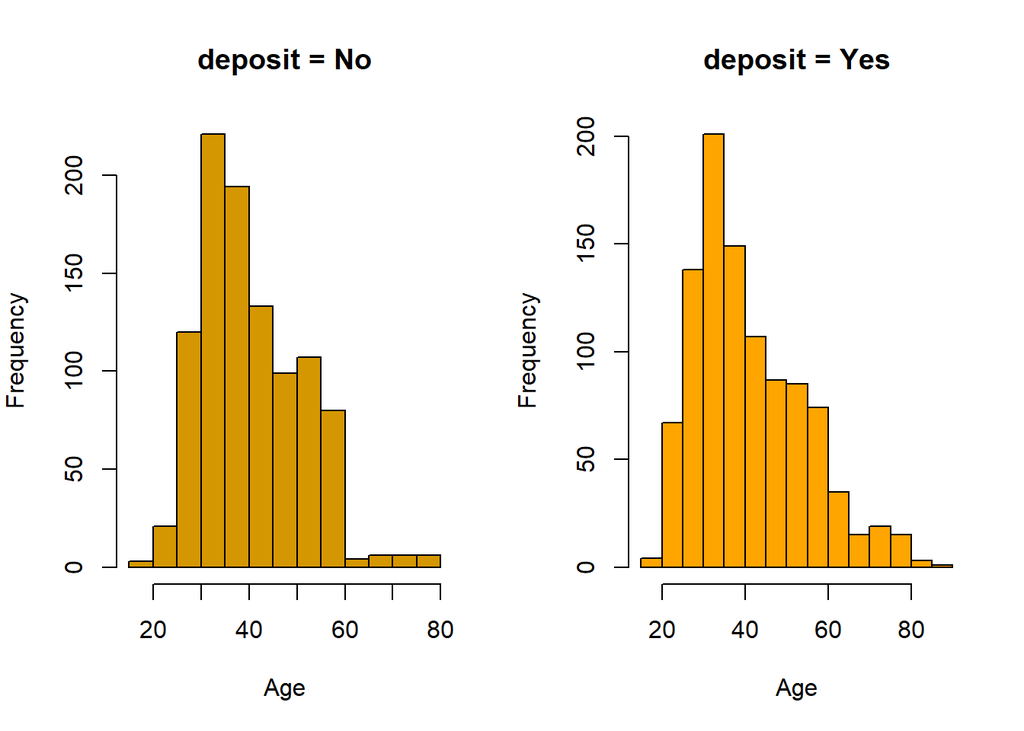

Para la variable “Age”, trazamos un histograma en relación a “Deposit”. A partir del gráfico, podemos observar que hay una mayor probabilidad de que los clientes de edades comprendidas entre los 60 y 80 años realicen el depósito.

*Boxplot Balance vs Deposit*

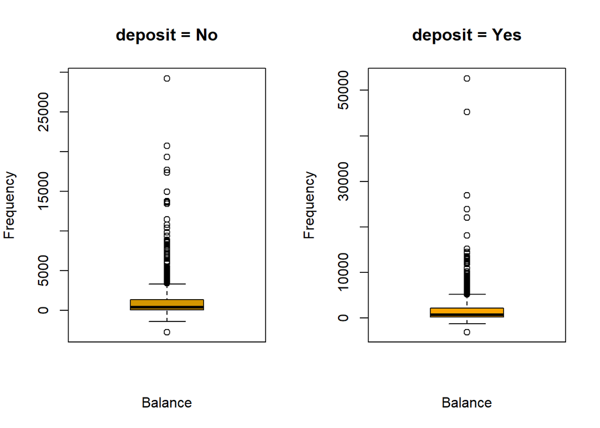

Luego, exploramos la relación entre la variable “Balance” y “Deposit” utilizando un boxplot. Calculamos las medias para ambos grupos: “Deposit = NO” con un valor de 1.276 y “Deposit = SI” con un valor de 1.912. Notamos que la media del balance es un 50% mayor en el grupo de clientes que realizaron el depósito en comparación con aquellos que no lo hicieron.

*Boxplot Campaign vs Deposit*

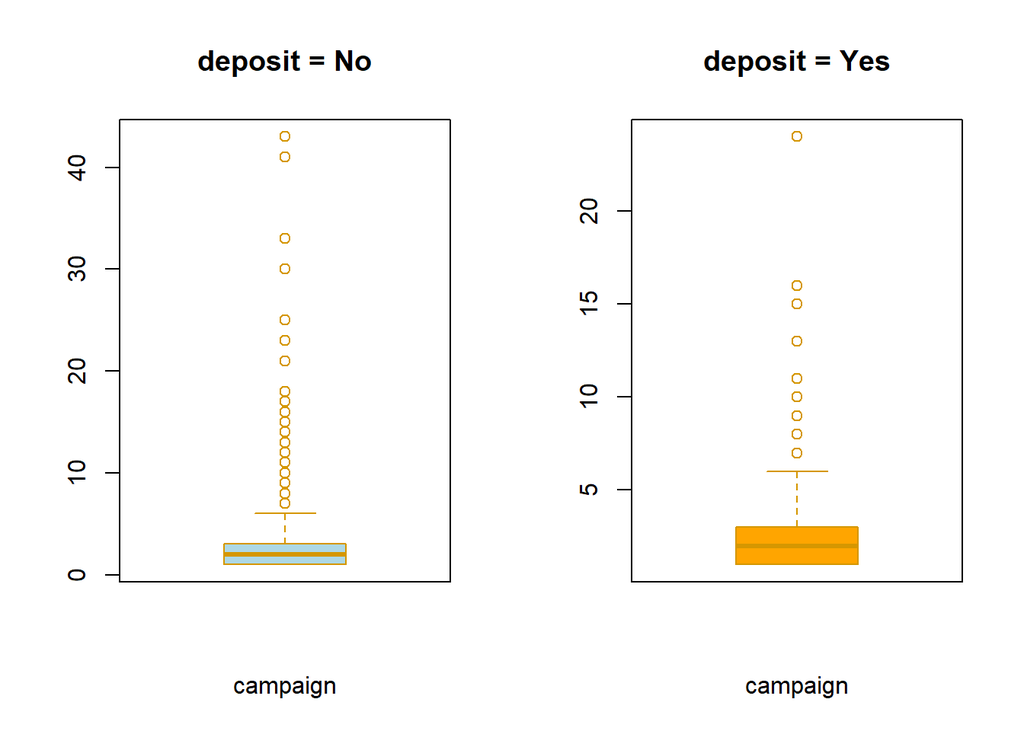

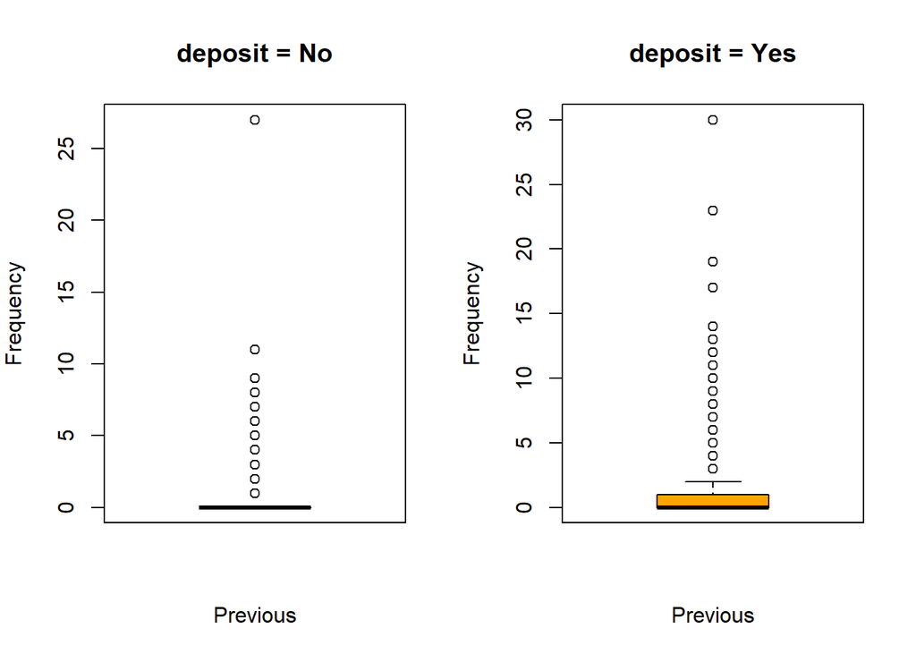

*Histograma Pdays vs Deposit*

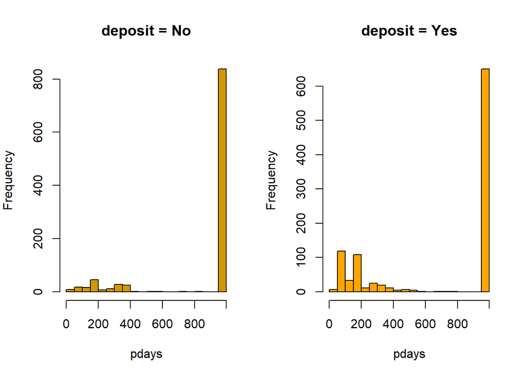

Por otra parte, las visualizaciones de boxplot nos permite observar la existencia de outleirs o valores atipicos en dichas distribuciones. (valores por fuera de los “bigotes” del boxplot).

A continuación, nos enfocamos en las variables categóricas presentes en el conjunto de datos.

**Variables Categoricas:**

[figure not shown]

[figure not shown]

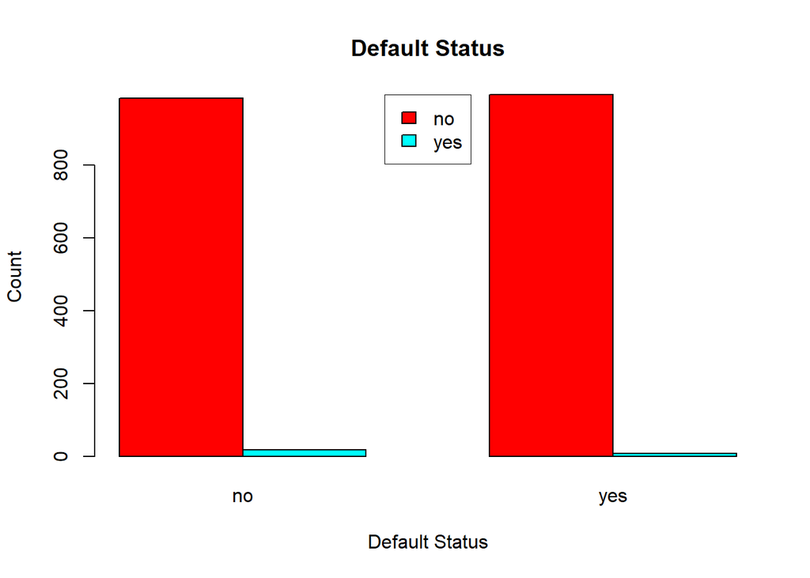

[figure not shown]

Además del análisis individual de las variables, también podemos explorar la correlación entre las variables numéricas utilizando un gráfico de estilo heatmap.

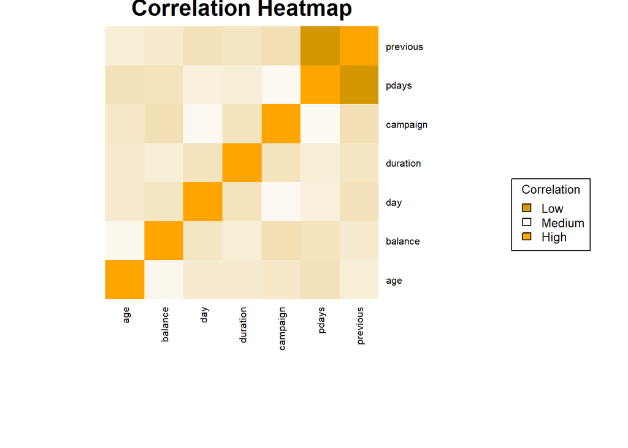

El resultado muestra que no existe una relación lineal clara entre todas las variables. Sin embargo, esto no descarta la posibilidad de que exista una relación no lineal entre ellas. Para investigar más a fondo, se puede considerar analizar posibles relaciones cuadráticas u otras formas de relación entre las variables.